# Temperature and DO

Nick Gubbins

1/26/2022

# Ecological Context

## Temperature as a master control

Available energy in a system is the master control on which, and at what rate, chemical reactions take place. Temperature is the most common, and most easily accessible, measurement of energy in a system. While other forms of energy ( such as turbulence) are critical for understanding aquatic systems, temperature can be easily and cheaply measured without effecting the system itself. For this week’s assignment, we will be getting more familiar with R by downloading and analyzing temperature data from the USGS.

## Power generation and water temperature

Rivers are often used as a water source for the production of steam in power generation. Generating stations draw in water from upstream, use it to create steam, use that steam to spin turbines, then (mostly) cool the steam, and re-release it downstream. You can clearly see the effect of this on the White River in downtown Indianapolis, IN. Station 03353000 is located just upstream of a major generating plant. Station 03353611 is just below it. The gauges are only ~2 miles apart. Let’s load in a few months of data from both and see how they differ.

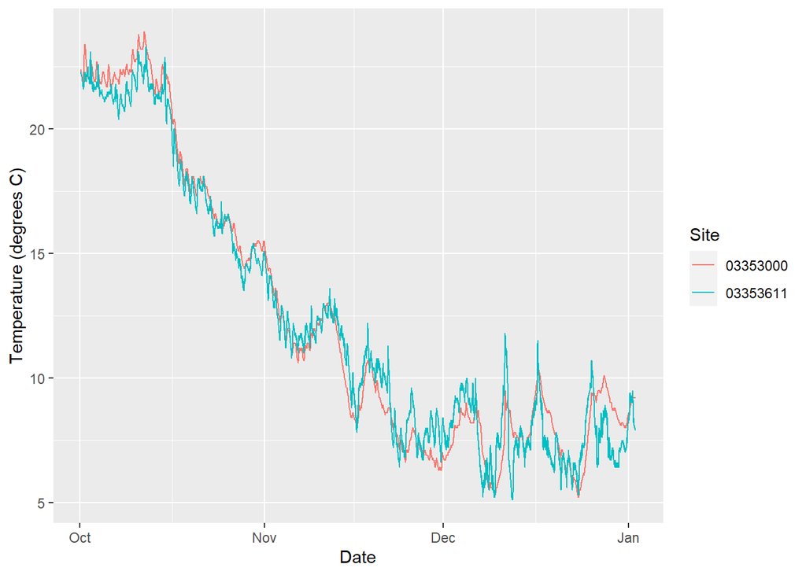

```r
ind <- data <- readNWISuv(siteNumbers = c('03353611', '03353000'),
                   parameterCd = '00010',
                   startDate = '2021-10-01',
                   endDate =  '2022-01-01')

ggplot(ind, aes(x = dateTime, y = X_00010_00000, color = site_no))+
  geom_line()+
  labs(x = 'Date', y = 'Temperature (degrees C)', color = 'Site')
```

## Dissolved oxygen and temperature

Dissolved oxygen is a key indicator of aquatic health. It is produced by photosynthesizing microbes and macrophytes. Heterotrophs, like fish and many kinds of bacteria, use dissolved oxygen in respiration. Healthy freshwater systems tend to have dissolved oxygen levels above 6 mg/L (usually around 80% saturation or higher). When dissolved oxygen levels get too low (below 6 mg/L) fish cannot spawn, as fish eggs rely on passive diffusion of dissolved oxygen to survive. Below 5 mg/L DO, you can see dramatic [fish kills](https://apnews.com/article/837ec91d3a1c4f86b1258be93cd865e8). These kills represent a huge disruption to the river’s food chain and a massive influx of organic matter, often leading to spiraling water quality issues.

# Assignment

## Q1:

Read in **mean daily** discharge (code ‘00060’), DO (code ‘00300’), and temperature (code ‘00010’) data from the South Platte River at Englewood, CO (‘06711565’) for the 2019 water year.

```r
data <- readNWISdv(siteNumbers = '06711565',
                   parameterCd = c('00060', '00300', '00010'),
                   startDate = '2018-10-01',
                   endDate =  '2019-9-30')
```

## Q2:

Look at the structure of the data in any way you choose.

```r
glimpse(data)
```

```
## Rows: 365
## Columns: 9
## $ agency_cd        <chr> "USGS", "USGS", "USGS", "USGS", "USGS", "USGS", "USGS~
## $ site_no          <chr> "06711565", "06711565", "06711565", "06711565", "0671~
## $ Date             <date> 2018-10-01, 2018-10-02, 2018-10-03, 2018-10-04, 2018~
## $ X_00010_00003    <dbl> 14.1, 14.9, 16.6, 16.3, 15.0, 12.9, 12.1, 10.4, 9.5, ~
## $ X_00010_00003_cd <chr> "A", "A", "A", "A", "A", "A", "A", "A", "A", "A", "A"~
## $ X_00060_00003    <dbl> 37.4, 39.5, 39.0, 38.1, 40.6, 95.0, 46.3, 87.2, 51.4,~
## $ X_00060_00003_cd <chr> "A", "A", "A", "A", "A", "A", "A", "A", "A", "A", "A"~
## $ X_00300_00003    <dbl> 8.4, 8.2, 8.1, 7.8, 7.9, 8.1, 8.1, 8.6, 8.7, 9.1, 9.3~
## $ X_00300_00003_cd <chr> "A", "A", "A", "A", "A", "A", "A", "A", "A", "A", "A"~
```

## Q3:

Rename your columns to something sensible, omit rows without complete observations, and reduce your data frame to only include the date and your data of interest.

```r
data <- data %>%
  rename(temp_C = X_00010_00003,
         q_cfs = X_00060_00003,
         do_mgl = X_00300_00003) %>%
  select(Date, temp_C, q_cfs, do_mgl) %>%
  na.omit()
```

## Q4:

Plot a time series of all three parameters the same graph.

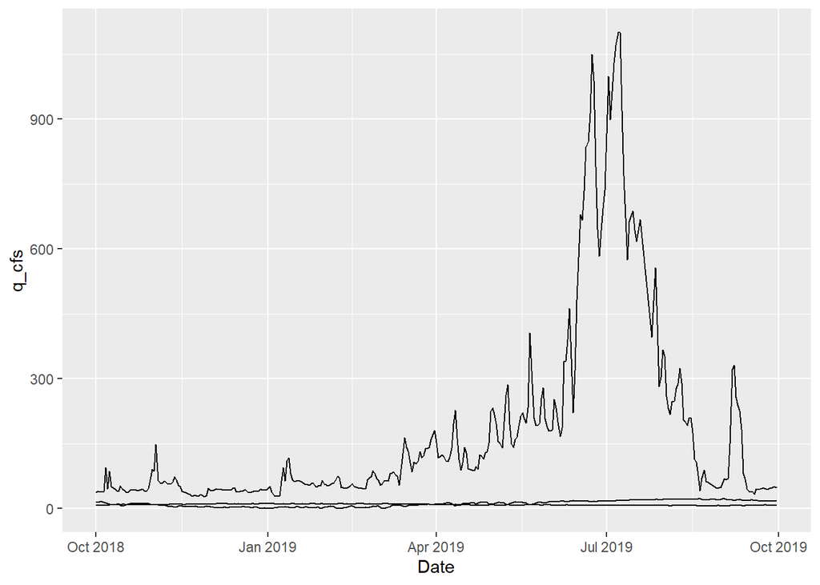

```r
ggplot(data, aes(x = Date))+
  geom_line(aes(y = q_cfs))+
  geom_line(aes(y = temp_C))+
  geom_line(aes(y = do_mgl))
```

## Q5:

This time series graph is not very useful to us. Why not? Give two examples of design choices you could make to improve its usefulness.

*The scale of discharge is way beyond that of temperature and DO. One way to improve this is to facet wrap by parameter. Another low-haning improvement would be to label the parameters by color.*

## Q6: Implement one of your proposed changes.

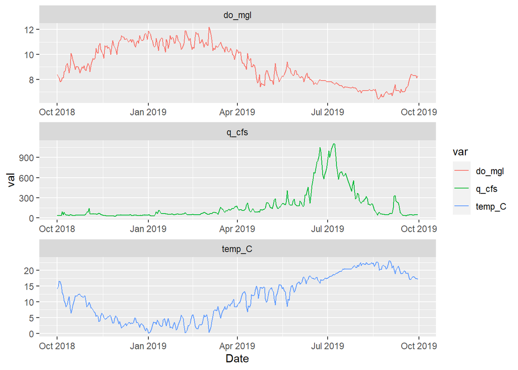

```r
data_long <- pivot_longer(data, cols = c(q_cfs, do_mgl, temp_C),
                          names_to = 'var', values_to = 'val')

ggplot(data_long, aes(x = Date, y = val, color = var))+
  geom_line()+
  facet_wrap(vars(var), ncol = 1, scales = 'free')
```

## Q7:

Scatterplots are a great way to compare correlations. Create two scatterplots. One of DO vs Q, the other of DO vs temperature.

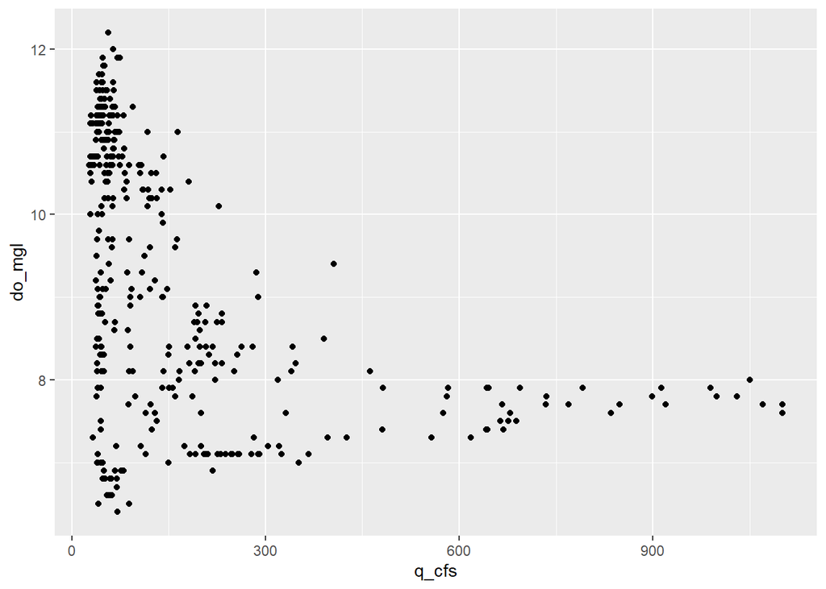

```r
ggplot(data, aes(x = q_cfs, y = do_mgl))+
  geom_point()
```

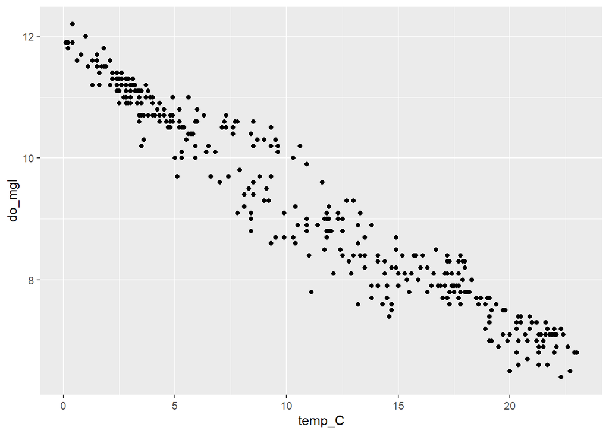

```r
ggplot(data, aes(x = temp_C, y = do_mgl))+
  geom_point()
```

## Q8:

Use the ‘cor()’ function to test which two variables are the most closely related (look at the ‘help’ window for documentation). Which relationship is it? Why do you think that is? Report your answers in complete sentences.

```r
cor(data$temp_C, data$do_mgl)
```

```
## [1] -0.9704405
```

```r
cor(data$q_cfs, data$do_mgl)
```

```
## [1] -0.444065
```

*Temperature is more closely correlated to DO than discharge. This is likely due to the lower solubility of gas in warm water and the energetics needed for photosynthesis.*

## Q9:

Imagine the city of Englewood is exploring building a coal-fired power plant using the South Platte as its water source and you have been hired on as a consultant. **Write a paragraph** brief for the city. Given that the benefits to the city are concrete, what issues would you raise? What effects do you think the plant would have on water temperatures and water quality? What data/assurances would you need to see before thinking the project should go ahead?